# Homework 11

Solutions will be available after Monday, November 9, 2026.

## Question 1: Implementing K-means

K-means is a relatively simple algorithm that we can write ourselves. For Questions 1 and 2, do not use an existing function that performs K-means directly.

Generate 10 observations with two independent standard normal coordinates. Set a random seed and report it. Randomly assign the observations to $K=2$ clusters, making sure neither cluster is empty. Let $C(i)$ denote the cluster assigned to observation $x_i$, and let $m_k$ denote the mean of cluster $k$.

1. Perform one iteration: calculate the cluster means, then assign each observation to its closest mean using Euclidean distance. Report the means and updated assignments, and plot the observations colored by their updated assignments.

```r
set.seed(11011)
n <- 10
K <- 2
X <- matrix(rnorm(n * 2), n, 2)
colnames(X) <- c("x1", "x2")

# squared Euclidean distance from every observation to every mean (n x K)
sq_dist <- function(X, M) {
  sapply(seq_len(nrow(M)), function(k) rowSums((X - rep(M[k, ], each = nrow(X)))^2))
}

# random start with 5 observations in each cluster, so neither is empty
init1 <- sample(rep(1:K, length.out = n))

# one iteration: means, then reassign
means0 <- t(sapply(1:K, function(k) colMeans(X[init1 == k, , drop = FALSE])))
assign1 <- max.col(-sq_dist(X, means0), ties.method = "first")

rownames(means0) <- paste("Cluster", 1:K)
means0
```

```
                  x1         x2
Cluster 1 -0.5497708 -0.5251732
Cluster 2 -0.3215648 -0.2284907
```

```r
data.frame(obs = 1:n, initial = init1, updated = assign1)
```

```
   obs initial updated
1    1       2       1
2    2       2       2
3    3       2       2
4    4       1       1
5    5       1       2
6    6       2       1
7    7       1       2
8    8       2       1
9    9       1       1
10  10       1       2
```

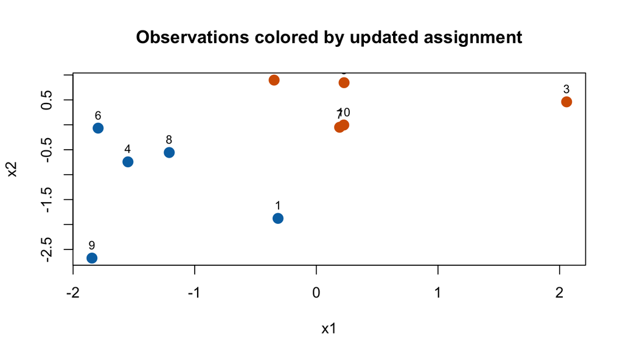

```r
cols <- c("#0072B2", "#D55E00")
plot(X, col = cols[assign1], pch = 19, cex = 1.5,
     main = "Observations colored by updated assignment")
text(X, labels = 1:n, pos = 3, cex = 0.8)
```

The cluster means computed from the random start are (-0.550, -0.525) for cluster 1 and (-0.322, -0.228) for cluster 2. After one reassignment, observations 1, 4, 6, 8, and 9 are in cluster 1 and observations 2, 3, 5, 7, and 10 are in cluster 2.

2. Write a function that repeats these two steps until the assignments stop changing or a specified maximum number of iterations is reached. Your function should work for a data matrix with any number of variables and a chosen number of clusters $K$. Start from a nonempty assignment to each cluster; if a cluster becomes empty during iteration, keep its previous mean. Recalculate the cluster means from the final assignments before returning them. Return the final assignments, cluster means, and within-cluster sum of squares,

   $$\sum_{k=1}^K\sum_{i:\,C(i)=k}\lVert x_i-m_k\rVert^2.$$

```r
my_kmeans <- function(X, init, K, max_iter = 100) {
  X <- as.matrix(X)
  cl <- init
  M <- matrix(0, K, ncol(X))
  for (k in 1:K) M[k, ] <- colMeans(X[cl == k, , drop = FALSE])
  for (it in 1:max_iter) {
    new_cl <- max.col(-sq_dist(X, M), ties.method = "first")
    changed <- any(new_cl != cl)
    cl <- new_cl
    # recompute means; an empty cluster keeps its previous mean
    for (k in 1:K) if (any(cl == k)) M[k, ] <- colMeans(X[cl == k, , drop = FALSE])
    if (!changed) break
  }
  wss <- sum((X - M[cl, , drop = FALSE])^2)
  list(cluster = cl, centers = M, wss = wss, iterations = it)
}
```

3. Apply your function to the same 10 observations from two different random initial assignments. Report the final plots, cluster means, and within-cluster sums of squares. Do the two runs produce the same grouping and objective value? Explain your findings.

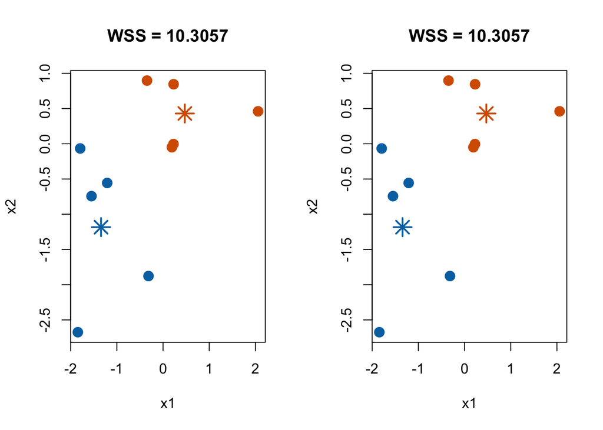

```r
set.seed(2)
init2 <- sample(rep(1:K, length.out = n))
run1 <- my_kmeans(X, init1, K)
run2 <- my_kmeans(X, init2, K)

par(mfrow = c(1, 2))
for (r in list(run1, run2)) {
  plot(X, col = cols[r$cluster], pch = 19, cex = 1.5,
       main = paste("WSS =", round(r$wss, 4)))
  points(r$centers, pch = 8, cex = 2, lwd = 2, col = cols)
}
```

```r
par(mfrow = c(1, 1))

run1$centers
```

```
           [,1]       [,2]
[1,] -1.3424162 -1.1835791
[2,]  0.4710806  0.4299152
```

```r
run2$centers
```

```
           [,1]       [,2]
[1,] -1.3424162 -1.1835791
[2,]  0.4710806  0.4299152
```

```r
c(run1 = run1$wss, run2 = run2$wss)
```

```
    run1     run2
10.30571 10.30571
```

```r
table(run1 = run1$cluster, run2 = run2$cluster)
```

```
    run2
run1 1 2
   1 5 0
   2 0 5
```

Both random starts ended at the same grouping and the same objective value. The cluster means are identical, (-1.342, -1.184) and (0.471, 0.430), and the within-cluster sum of squares is 10.306 in both runs. The table of the two sets of assignments has all 5 observations in cluster 1 of run 1 also in cluster 1 of run 2, and all 5 in cluster 2 in cluster 2, so the groupings match exactly (the cluster labels did not switch).

This agreement is not guaranteed. K-means only finds a local minimum of the within-cluster sum of squares, and a different starting assignment can lead to a different grouping with a higher objective value. Here there are only 10 points and 2 clusters, and the two groups are fairly well separated along the diagonal, so both starts reach the same solution. With more observations, more clusters, or less clear groups, it would be better to run several random starts and keep the one with the smallest within-cluster sum of squares.

## Question 2: Image color compression

Pick your favorite color image and use your K-means function from Question 1 to cluster its pixels. For computational efficiency, resize the image to no more than $200\times200$ pixels and use its three RGB color channels.

1. Plot the original image and report its dimensions. Transform it into a data matrix with one observation per pixel and three variables: red, green, and blue. Report the dimensions of this matrix.

```r
library(jpeg)
img <- readJPEG("CloudCity.jpg")
dim(img)
```

```
[1]  576 1024    3
```

```r
new_w <- 200
new_h <- round(dim(img)[1] * new_w / dim(img)[2])
r_idx <- round(seq(1, dim(img)[1], length.out = new_h))
c_idx <- round(seq(1, dim(img)[2], length.out = new_w))
small <- img[r_idx, c_idx, , drop = FALSE]
dim(small)
```

```
[1] 112 200   3
```

[figure not shown]

```r
plot(as.raster(img))
```

```r
P <- cbind(R = as.vector(small[, , 1]), G = as.vector(small[, , 2]), B = as.vector(small[, , 3]))
dim(P)
```

```
[1] 22400     3
```

The original image is 576 pixels high and 1024 pixels wide, with 3 color channels. I resized it to 112 by 200 pixels by keeping evenly spaced rows and columns, which keeps the same shape as the original. The pixel data matrix has one row per pixel and three columns (red, green, blue), so its dimensions are 22,400 by 3.

2. For $K=2,3,5,10$, apply your function to the pixel data. Report the cluster means and within-cluster sum of squares for each $K$. Reconstruct and plot each compressed image by replacing every pixel with its assigned cluster mean. Use the same RGB scale for all fits.

```r
set.seed(11)
Ks <- c(2, 3, 5, 10)
fits <- list()
for (K in Ks) {
  init <- sample(rep(1:K, length.out = nrow(P)))
  fits[[as.character(K)]] <- my_kmeans(P, init, K)
}

for (K in Ks) {
  f <- fits[[as.character(K)]]
  colnames(f$centers) <- c("R", "G", "B")
  cat("\nK =", K, " WSS =", round(f$wss, 2), " iterations =", f$iterations, "\n")
  print(round(f$centers, 3))
}
```

```
K = 2  WSS = 861.43  iterations = 5
         R     G     B
[1,] 0.877 0.562 0.206
[2,] 0.323 0.297 0.160

K = 3  WSS = 499.65  iterations = 13
         R     G     B
[1,] 0.952 0.628 0.226
[2,] 0.241 0.272 0.164
[3,] 0.591 0.379 0.155

K = 5  WSS = 309.49  iterations = 31
         R     G     B
[1,] 0.969 0.652 0.235
[2,] 0.415 0.331 0.144
[3,] 0.158 0.856 0.906
[4,] 0.175 0.241 0.172
[5,] 0.710 0.417 0.161

K = 10  WSS = 134.28  iterations = 100
          R     G     B
 [1,] 0.151 0.881 0.929
 [2,] 0.995 0.914 0.571
 [3,] 0.997 0.707 0.283
 [4,] 0.104 0.200 0.177
 [5,] 0.765 0.436 0.163
 [6,] 0.944 0.588 0.172
 [7,] 0.570 0.371 0.157
 [8,] 0.256 0.253 0.126
 [9,] 0.160 0.297 0.252
[10,] 0.389 0.327 0.142
```

[figure not shown]

```r
recon <- function(fit) {
  C <- fit$centers[fit$cluster, ]
  array(c(C[, 1], C[, 2], C[, 3]), dim = dim(small))
}
par(mfrow = c(2, 3), mar = c(1, 1, 2, 1))
plot(as.raster(small)); title("Original")
for (K in Ks) {
  plot(as.raster(recon(fits[[as.character(K)]])))
  title(paste("K =", K))
}
par(mfrow = c(1, 1))
```

For each K, the cluster means (R, G, B on a 0 to 1 scale) and the within-cluster sum of squares are printed above, and the reconstructed images are shown next to the original. The within-cluster sums of squares were:

| K | Within-cluster sum of squares |
| --- | --- |
| 2 | 861.43 |
| 3 | 499.65 |
| 5 | 309.49 |
| 10 | 134.28 |

The sum of squares falls every time K increases, as expected. At K = 2 the image is only a warm orange region and a dark region. At K = 3 a middle brown is added, so the clouds look smoother. At K = 5 one cluster has a center of about (0.16, 0.86, 0.91), which is the bright blue of the glow under the ship, so this is the first K where that color appears. At K = 10 there are separate colors for the bright sun, the yellow and orange sky, and the different dark and brown cloud shades, so the image looks closest to the original. The K = 10 run used all 100 iterations without the assignments settling completely, so its result may be slightly improved with more iterations, but the change would be small.

3. Which value of $K$ would you choose for this image? Briefly justify your choice using the reconstructed images and the within-cluster sums of squares.

I would choose K = 5. Going from K = 2 to 3 and from 3 to 5 reduces the sum of squares a lot (861 to 500 to 309), and K = 5 is where the main colors of the picture, including the blue glow of the ship, are all present. Going from K = 5 to K = 10 doubles the number of colors and lowers the sum of squares by about 175, which is a smaller gain per added cluster, and the picture is only somewhat smoother. K = 10 does look the most like the original, so it would be the better choice if image quality matters more than storing few colors, but K = 5 gives a recognizable image with only 5 colors.

## Question 3: Hierarchical clustering of cars

The file `data/mtcars.csv` contains 11 numerical variables for 32 cars, including fuel economy, horsepower, and weight. The `car` column gives the model names; use it to label observations, not as a clustering variable. You may use existing hierarchical clustering functions for this question.

1. Standardize each numerical variable to have mean 0 and standard deviation 1. Using Euclidean distance, perform hierarchical clustering with single, complete, and average linkage. Plot the three dendrograms with the car names and compare the results.

```r
mt <- read.csv("data/mtcars.csv")
cars <- mt$car
Xm <- mt[, names(mt) != "car"]

Z <- scale(Xm)            # mean 0, sd 1 for each variable
rownames(Z) <- cars
d <- dist(Z, method = "euclidean")

hc_single   <- hclust(d, method = "single")
hc_complete <- hclust(d, method = "complete")
hc_average  <- hclust(d, method = "average")
```

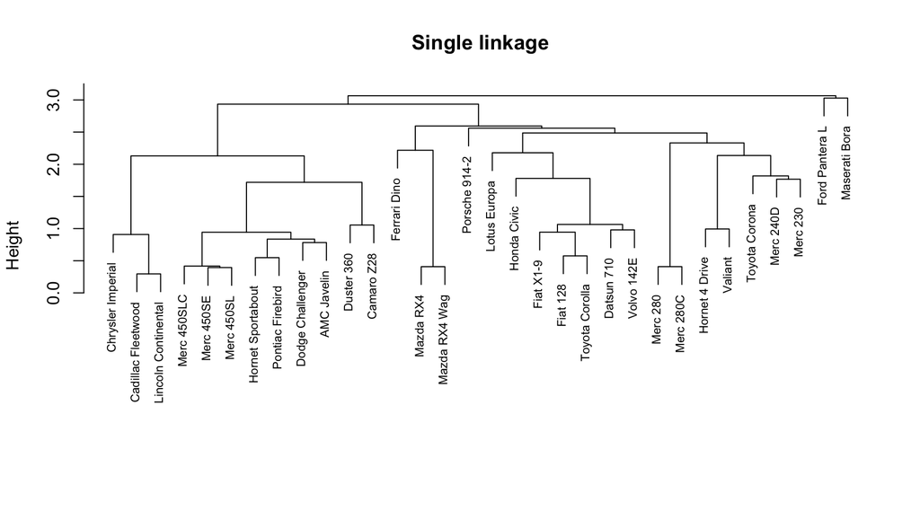

```r
plot(hc_single,   main = "Single linkage",   xlab = "", sub = "", cex = 0.7)
```

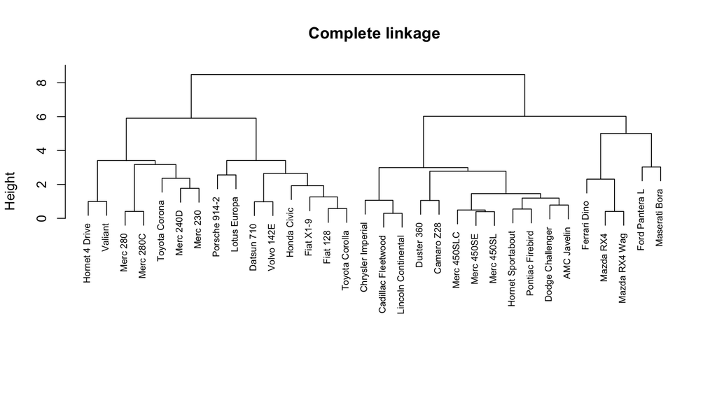

```r
plot(hc_complete, main = "Complete linkage", xlab = "", sub = "", cex = 0.7)
```

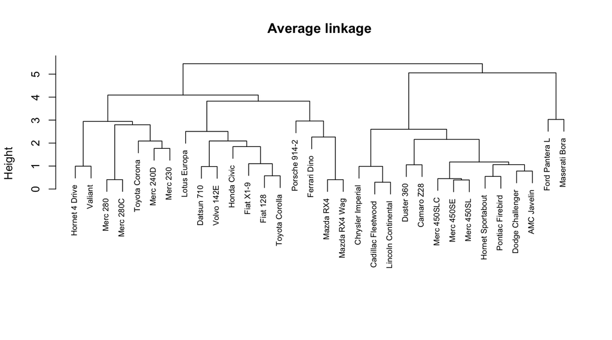

```r
plot(hc_average,  main = "Average linkage",  xlab = "", sub = "", cex = 0.7)
```

2. Choose one linkage method and a number of clusters that you consider reasonable. Report the cluster memberships and a table of cluster means on the original variable scales. Describe the main characteristics of the groups and explain your choice using the dendrogram and table. Briefly explain why standardizing the variables matters for this analysis.

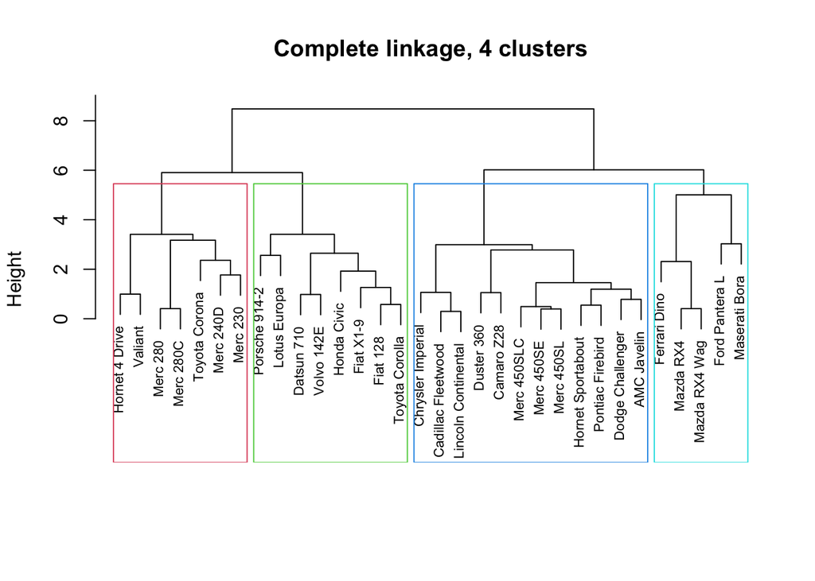

```r
hc <- hc_complete
k <- 4
grp <- cutree(hc, k = k)

plot(hc, main = "Complete linkage, 4 clusters", xlab = "", sub = "", cex = 0.7)
rect.hclust(hc, k = k, border = 2:5)
```

```r
for (g in 1:k) cat("Cluster", g, ":", paste(cars[grp == g], collapse = ", "), "\n\n")
```

```
Cluster 1 : Mazda RX4, Mazda RX4 Wag, Ford Pantera L, Ferrari Dino, Maserati Bora

Cluster 2 : Datsun 710, Fiat 128, Honda Civic, Toyota Corolla, Fiat X1-9, Porsche 914-2, Lotus Europa, Volvo 142E

Cluster 3 : Hornet 4 Drive, Valiant, Merc 240D, Merc 230, Merc 280, Merc 280C, Toyota Corona

Cluster 4 : Hornet Sportabout, Duster 360, Merc 450SE, Merc 450SL, Merc 450SLC, Cadillac Fleetwood, Lincoln Continental, Chrysler Imperial, Dodge Challenger, AMC Javelin, Camaro Z28, Pontiac Firebird
```

```r
means <- aggregate(Xm, by = list(cluster = grp), FUN = mean)
means$n <- as.vector(table(grp))
knitr::kable(means, digits = 2)
```

| cluster | mpg | cyl | disp | hp | drat | wt | qsec | vs | am | gear | carb | n |
| --- | --- | --- | --- | --- | --- | --- | --- | --- | --- | --- | --- | --- |
| 1 | 18.50 | 6.80 | 223.40 | 198.80 | 3.84 | 3.00 | 15.62 | 0.00 | 1 | 4.60 | 5.20 | 5 |
| 2 | 28.08 | 4.00 | 93.61 | 81.88 | 4.18 | 2.04 | 18.45 | 0.88 | 1 | 4.25 | 1.50 | 8 |
| 3 | 20.74 | 5.14 | 175.11 | 102.14 | 3.57 | 3.19 | 19.97 | 1.00 | 0 | 3.57 | 2.14 | 7 |
| 4 | 15.05 | 8.00 | 357.62 | 194.17 | 3.12 | 4.10 | 17.14 | 0.00 | 0 | 3.00 | 3.08 | 12 |

- **Cluster 1 (5 cars: Mazda RX4, Mazda RX4 Wag, Ford Pantera L, Ferrari Dino, Maserati Bora):** powerful sports cars, all with manual transmissions. They have 6 or 8 cylinders, high horsepower (about 199), mpg of 18.5, 4 to 5 gears on average, and many carburetors (5.2).
- **Cluster 2 (8 cars, such as Honda Civic, Fiat 128, Toyota Corolla, Porsche 914-2):** small, light, fuel-efficient cars. They all have 4 cylinders, the highest mpg (28.1), the lowest horsepower (82) and weight (2.04), and are all manual.
- **Cluster 3 (7 cars, such as Hornet 4 Drive, Valiant, Merc 240D, Merc 230, Toyota Corona):** mid-size automatic cars with moderate size and power. They have 4 to 6 cylinders, mpg of 20.7, horsepower of 102, weight of 3.19, and the slowest quarter-mile times (qsec about 20).
- **Cluster 4 (12 cars, such as Cadillac Fleetwood, Lincoln Continental, Merc 450SE, Duster 360):** large, heavy, powerful cars. They all have 8 cylinders and are all automatic, with the largest displacement (358) and weight (4.1), high horsepower (194), and the lowest mpg (15).

Standardizing matters because the variables are measured on very different scales. Displacement is in the hundreds and horsepower in the tens to hundreds, while weight is around 3, and variables like vs and am only take the values 0 and 1. Euclidean distance on the raw data would be dominated by displacement and horsepower, and the other variables would barely affect which cars are grouped together. Standardizing gives every variable mean 0 and standard deviation 1, so each one has a comparable influence on the distances.